# Wow, even mindfulness might have some “contraindications” 😯

personality well-being experiments causal inference mindfulness

…at least when it’s used at work…

Luděk Stehlík https://www.linkedin.com/in/ludekstehlik/  
2026-11-24

Not an expert on mindfulness, especially in an org context. Most of what I’ve read about it has focused on the benefits, like [being less likely to avoid uncomfortable information](https://blog-about-people-analytics.netlify.app/posts/2023-06-05-mindfulness-and-objectivity/). So this particular finding caught me by surprise.

In a randomized field experiment, employees high in Machiavellianism who received mindfulness training reported more contempt, anger, and disgust toward coworkers than those in either control group (regulated breathing or a waitlist). Those feelings were also linked to more self-reported workplace incivility.

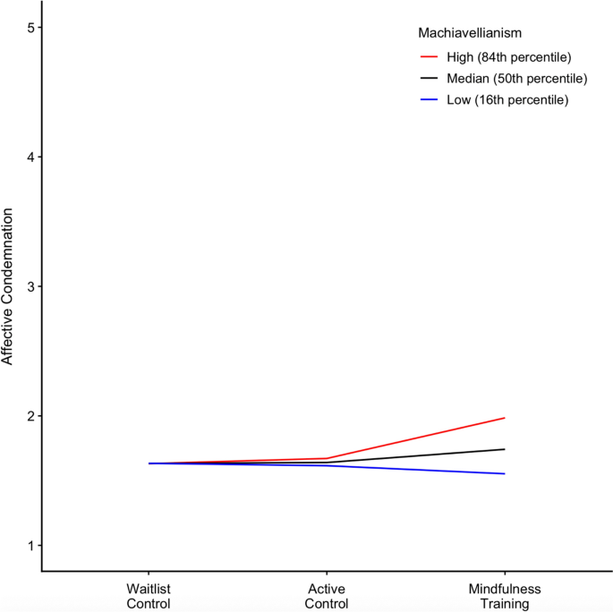

Chart showing predicted scores for contempt, anger, and disgust toward coworkers. In the mindfulness group, scores were about 1.6 at low Machiavellianism and 2.0 at high Machiavellianism. Scores stayed near 1.6 across Machiavellianism levels in both the breathing and waitlist groups.  
Figure 2 from [Kay (2026)](https://link.springer.com/article/10.1007/s10551-026-06513-3#Fig2). [CC BY-NC-ND 4.0](https://creativecommons.org/licenses/by-nc-nd/4.0/).

A little reminder that what helps some people can backfire for others. Also a good selling point for estimating heterogeneous treatment effects. The average can hide who responds differently.

And a separate point about having a testable theory of how things might work. Of all the things you could look at here, would Machiavellianism have come to mind? Kay’s theory gives a concrete reason to test it. His idea is that paying closer attention to what you’re feeling can bring existing contempt for coworkers into sharper focus.

Link to the paper 👉 [The Dark Side of Mindfulness at Work](https://link.springer.com/article/10.1007/s10551-026-06513-3).

Comment on this article Share:

Enjoy this blog? Get notified of new posts via email: